# Анализ связи между наборами данных

## Вы сможете

- Количественно оценить степень взаимосвязи между несколькими наборами данных.
- Протестировать гипотезу о наличии в данных некоторого специфического паттерна, используя метод модельных матриц.
- Найти оптимальное сочетание признаков, не вошедших в ординацию, которые “объясняют” характер взаиморасположения точек на ординации

## Ординация растительности на пастбищах северных оленей

Данные из работы  
Väre, H., Ohtonen, R. and Oksanen, J. (1995)

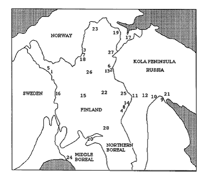

из Väre, Ohtonen & Oksanen (1995)

```r
library(vegan)
library(ggplot2)
data(varespec)
data(varechem)
```

Два набора данных:

- `varespec` - Описание растительности (обилия отдельных видов)
- `varechem` - Параметры среды на участках (Концентрации веществ)

## Задание

1. Используя средства пакета “ggplot2”, постройте ординацию описаний растительности в осях MDS.
2. Раскрасьте точки в соответствии с концентрацией Al.
3. На диаграмме приведите величину стресса для данной ординации

Hint. В качестве меры различия используйте коэффициент Брея-Куртиса

## Решение

```r
veg_ord <- metaMDS(varespec, trace = FALSE)
veg_MDS <- as.data.frame(veg_ord$points)
```

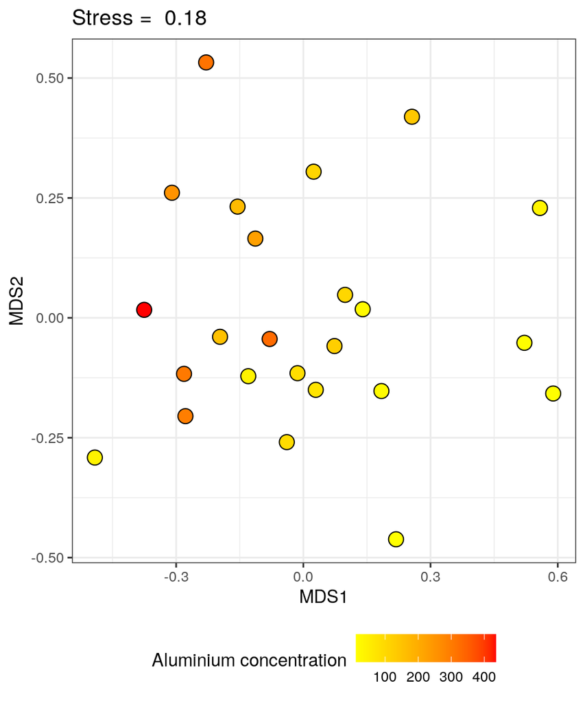

```r
library(ggplot2)
Pl_mds <-
  ggplot(veg_MDS, aes(x = MDS1, y = MDS2,
                    fill = varechem$Al))  +
  geom_point(shape=21, size =4)+
  ggtitle(paste("Stress = ", round(veg_ord$stress, 2))) +
  theme_bw() +
  theme(legend.position = "bottom") +
  labs(fill = "Aluminium concentration") +
  scale_fill_gradient(high = "red", low = "yellow")
```

## Анализ связи с переменными c помощью функции envfit()

**Задание**: Постройте рисунок, который будет отражать связь полученной ординации с изученными переменными среды (датасет `varechem`)

## Решение

```r
env_fit <- envfit(veg_ord ~ ., data = varechem)
```

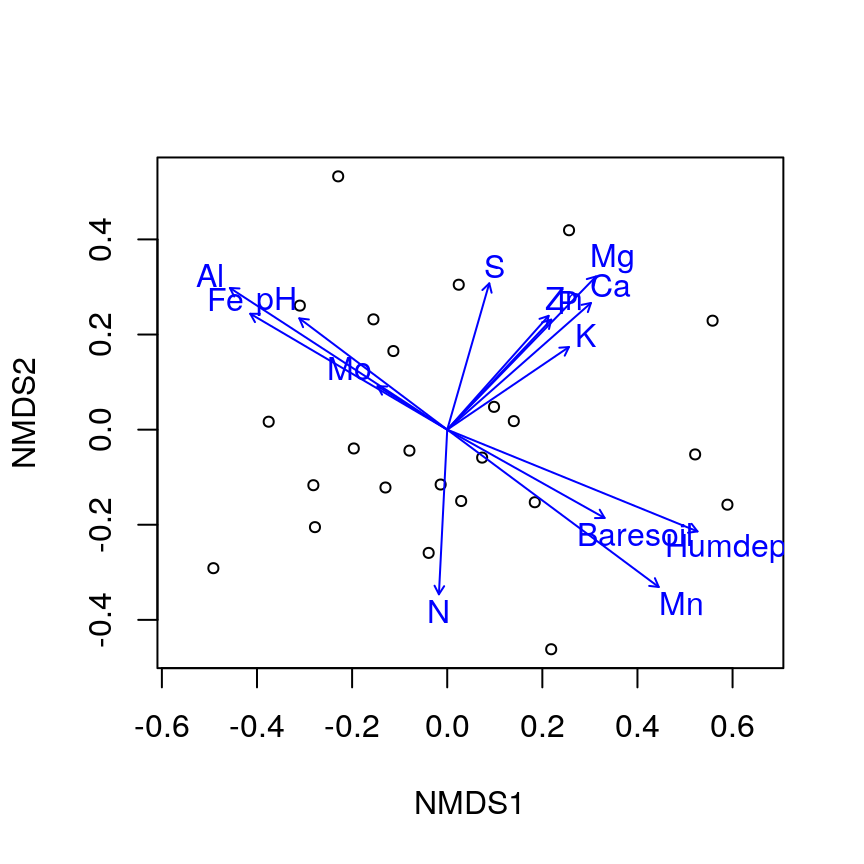

```r
ordiplot(veg_ord, display = "site")
plot(env_fit)
```

## Анализ связи с переменными c помощью функции ordisurf()

**Задание**: Постройте рисунок, который будет отражать связь полученной ординации с концентрацией Mn и Al

## Решение

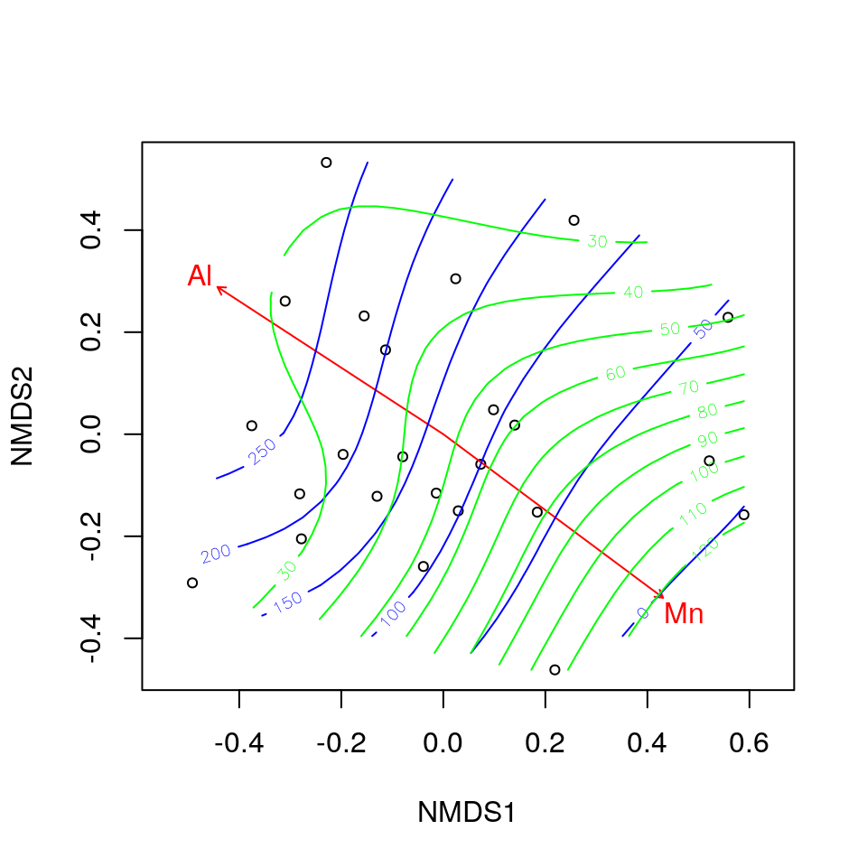

```r
env_fit2 <- envfit(veg_ord ~ Al + Mn, data = varechem)
plot(veg_ord, display = "site")
plot(env_fit2, col = "red")
ordisurf(veg_ord, varechem$Al, add = TRUE, col="blue")
ordisurf(veg_ord, varechem$Mn, add = TRUE, col="green")
```

**Вопрос:**  
Сможем ли мы на основе данных, полученных с помощью функций `envfit()` или `ordisurf()`, построить оптимальную модель, описывающую связь структуры сообществ и параметров среды?

## Тест Мантела

## Постановка проблемы

Нам необходимо оценить связаны ли, в целом, два набора данных и оценить силу этой связи

**Похожие задачи**

> Зависит ли растительность от параметров среды?  
> Связаны ли морфологические признаки и экспрессия генов?  
> Связаны ли характеристики паразитов и хозяев?

и т.п.

## Метод сравнения сопряженных матриц, описывающих попарные расстояния (или сходства), был предложен Натаном Мантелом

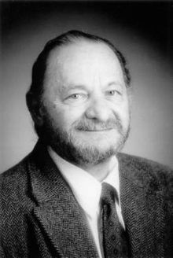

## Корреляция матриц сходства/различия

Если две матрицы сопряжены, то меры сходства/различия в одной матрице должны быть подобны мерам сходства/различия в другой матрице

```r
dist_com <- vegdist(varespec, method = "bray")
dist_chem <- vegdist(varechem, method = "euclidean")
```

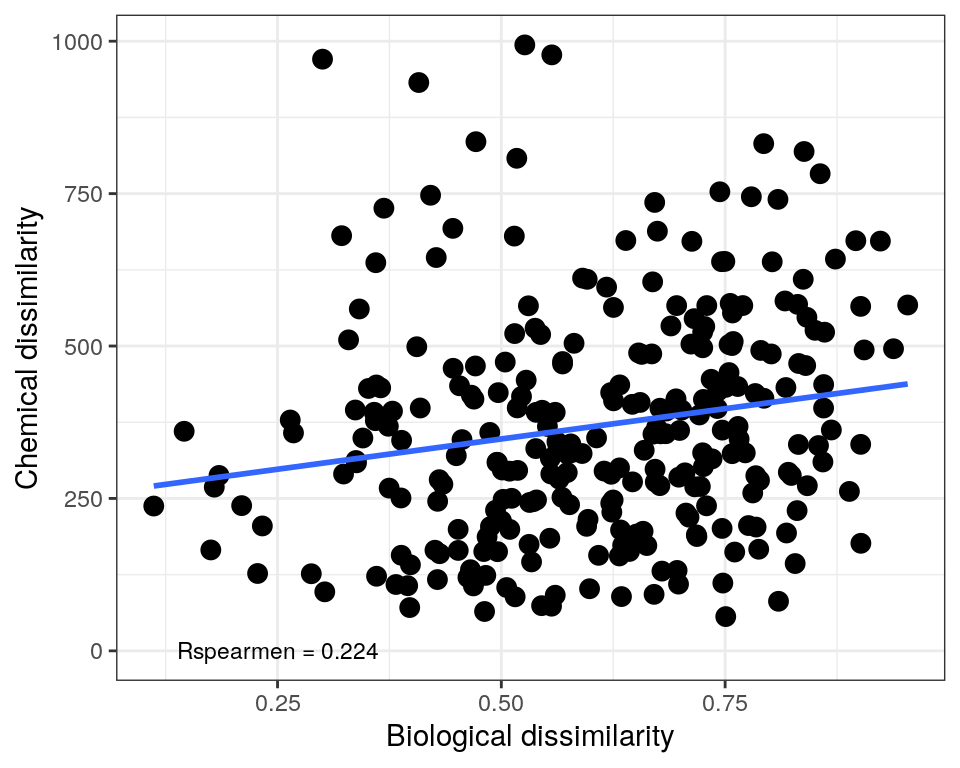

## Корреляция матриц сходства/различия

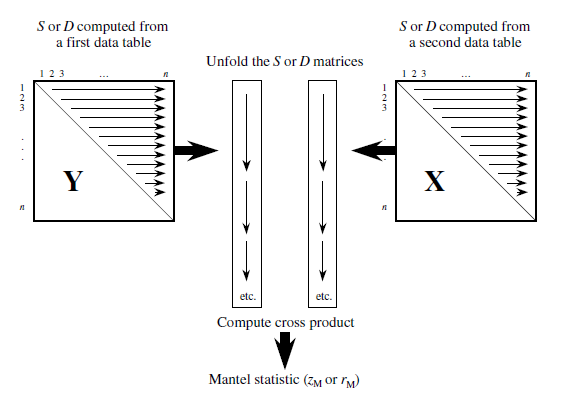

Вопрос: Как можно определить статистическую значимость полученного коэффициента корреляции?

- Внимание! Значимость этой корреляции нельзя оценивать как для обычной корреляции, например функцией `cor.test()` или по таблице пороговых значений коэффициента корреляции.

## Пермутационные методы оценки статистической значимости

– Друг мой, – отвечал Диоталлеви, – ты никогда ничего не поймешь. Да, это правда, что Тора – я имею в виду, разумеется, видимую Тору – есть лишь одна из перестановок-*пермутаций* букв, составляющих вековечную Тору, какою создал ее Творец и какой ее дал Адаму. Умберто Эко  
“Маятник Фуко”

## Тестирование простейшей гипотезы

Создадим две выборки из популяций с нормальным распределением признака, с заведомо отличающимися средними значениями

```r
set.seed(12345)

male <- rnorm(100, 130, 5)
female <- rnorm(100, 129,5)
```

## Частотное распределение этих двух выборок выглядит так

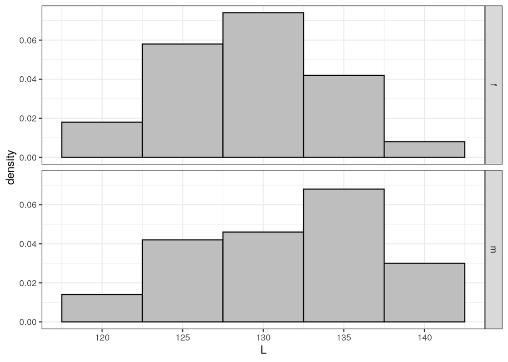

## Сравним две выборки с помощью t-критерия Стьюдента

Какая статистика используется в t-критерии?

- \(t= \frac {X1-X2} {SE}\)

## Сравним две выборки с помощью t-критерия Стьюдента

Результаты

```r
t <- t.test(male, female)
t
```

```
##
##  Welch Two Sample t-test
##
## data:  male and female
## t = 3, df = 196, p-value = 0.009
## alternative hypothesis: true difference in means is not equal to 0
## 95 percent confidence interval:
##  0.516 3.484
## sample estimates:
## mean of x mean of y
##       131       129
```

Что означает выражение p-value=0.009?

## Пермутационный подход к тестированию

Если две сравниваемые выборки взяты из одной совокупности (справедлива \(H_0\)), то обмен элементами между ними ничего не изменит. Степень различия между выборками (значение статистики) останется более или менее тем же самым.

**Пермутации - это перестановки.**

Полное количество пермутаций (при равном количестве объектов в двух группах) будет вычисляться по следующей формуле:

\[K= \frac{(2n)!}{(2!(n!)^2)}\]

При большом объеме выборок это огромное число!

В таких случаях используют метод Монте-Карло.

## Пермутационный метод вручную

Применим этот метод (на очень примитивном уровне) к нашим двум выборкам, описывающим размеры мальчиков и девочек (векторы male и female).

```r
head (male)
```

```
## [1] 133 134 129 128 133 121
```

```r
head (female)
```

```
## [1] 130 123 131 122 130 126
```

## Пермутационный метод вручную

Введем статистику

\[t= \frac {X_1 - X_2}{ \sqrt {SE_1^2+SE_2^2}}\]

Вычислим значение этой статистики при сравнении векторов male и female

```r
SE_m <- sd(male) / sqrt(length(male))
SE_f <- sd(female) / sqrt(length(female))
t_initial <- (mean(male) - mean(female))/sqrt(SE_m^2 + SE_f^2)
```

Полученное значение t = 2.657

## Пермутационный метод вручную

При пермутациях мы должны поменять местами, например, male[10] = 125.403 и female[20] = 128.655. А еще лучше поменять случайное количество элементов одной выборки на случайное количество элементов из другой выборки.

```r
f <- female
m <- male
num_perm <- sample(1:100,1)
order_m <- sample (1:100, num_perm)
order_f <- sample (1:100, num_perm)
f[order_f] <- male[order_f]
m[order_m] <- female[order_f]
SE_m <- sd(m) / sqrt(length(m))
SE_f <- sd(f) / sqrt(length(f))
t_p=(mean(m) - mean(f))/sqrt(SE_m^2 + SE_f^2)
```

После этой пермутации у нас получилось значение \(t_{perm}\) = -2.332, а исходное значение было t = 2.657

## Пермутационный метод вручную

Теперь нужно провести процедуру пермутации много раз и получить распределение значений статистики \(t_{perm}\)

```r
Nperm=10000
tperm <- rep(NA, Nperm)

set.seed(12345)
for (i in 1:(Nperm-1))
  {
  BOX <- c(male,female)
  ord <-sample(1:200, 200)
  f <- BOX[ord[1:100]]
  m <- BOX [ord[101:200]]
  SE_m <- sd(m) / sqrt(length(m))
  SE_f <- sd(f) / sqrt(length(f))
  tperm[i]=(mean(m) - mean(f))/sqrt(SE_m^2 + SE_f^2)
  }
head(tperm)
```

```
## [1] -0.508 -0.420 -2.240 -0.781  0.901 -1.152
```

## Пермутационный метод вручную

Посмотрим в конец этого вектора

```r
tail (tperm)
```

```
## [1] -0.4985  1.6344 -0.7864 -0.0249  1.0292      NA
```

Последнее 10000-е значение не заполнено!  
В него надо вписать исходное, полученное до пермутаций, значение t = 2.657. Это необходимо, так как мы тестируем гипотезу о принадлежности этого значения случайному распределению.

```r
tperm [Nperm] <- t_initial
```

## Пермутационный метод вручную

Построим частотное распределение пермутированных значений статистики \(t_{perm}\)

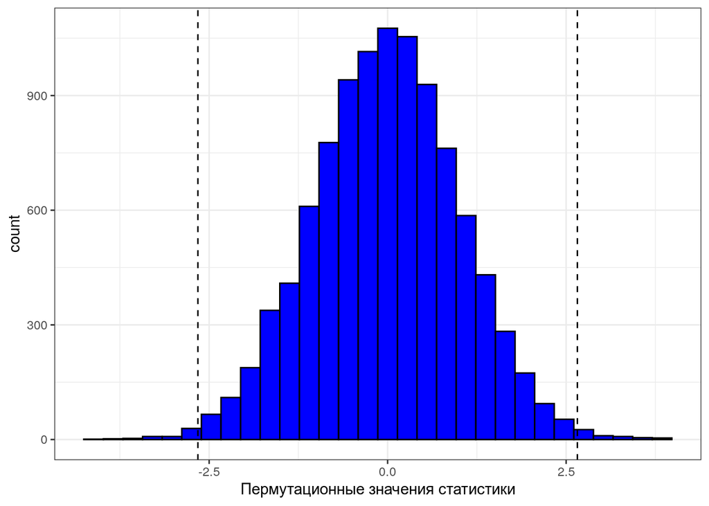

## Пермутационный метод вручную

Рассчитаем величину уровня значимости \(p_{perm}= \frac{N_{t_{perm}>=t}}{N_{perm}}\)

```r
p_perm <- length(tperm[tperm >= t_initial] | tperm[tperm <= -t_initial] ) / Nperm
```

Мы получили уровень значимости \(p_{perm}\) = 0.005

Сравним его с уровнем значимости, вычисленным с помощью параметрического t-критерия p=0.009

Они оба близки и оба выявляют значимые различия!

## Пермутационная оценка коэффициента корреляции

Создадим два скоррелированных вектора

```r
library(MASS)
set.seed(1234567)
mu <- c(10, 20) #Вектор средних значений
Sigma <- matrix(.7, nrow=2, ncol=2)
diag(Sigma) <- c(1, 3)

# Sigma Ковариационная матрица

dat <- as.data.frame(mvrnorm(n=100, mu=mu, Sigma=Sigma))
# Датафрейм с двумя скоррелированными переменными

cor.test(dat$V1, dat$V2, method = "spearman")
```

```
##
##  Spearman's rank correlation rho
##
## data:  dat$V1 and dat$V2
## S = 87860, p-value = 0.0000009
## alternative hypothesis: true rho is not equal to 0
## sample estimates:
##   rho
## 0.473
```

## Пермутационная оценка коэффициента корреляции

```r
library(coin)
spearman_test( V1 ~ V2, data = dat, distribution = approximate(B=9999))
```

```
##
##  Approximative Spearman Correlation Test
##
## data:  V1 by V2
## Z = 5, p-value <0.0001
## alternative hypothesis: true rho is not equal to 0
```

## Проверка статистической значимости Мантеловской корреляции

Для оценки достоверности Мантеловской корреляции применяется пермутационная процедура. Эта процедура реализована в функции `mantel()` из пакета `vegan`

```r
options(digits=4)
mant <- mantel(dist_com, dist_chem, method="pearson", permutations = 999)
mant
```

```
##
## Mantel statistic based on Pearson's product-moment correlation
##
## Call:
## mantel(xdis = dist_com, ydis = dist_chem, method = "pearson",      permutations = 999)
##
## Mantel statistic r: 0.182
##       Significance: 0.027
##
## Upper quantiles of permutations (null model):
##   90%   95% 97.5%   99%
## 0.109 0.150 0.184 0.202
## Permutation: free
## Number of permutations: 999
```

Вероятность наблюдать такое значение при условии, что верна \(H_0\), равна 0.027

## Частная Мантеловская корреляция

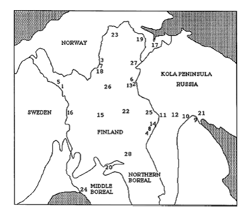

из Väre, Ohtonen & Oksanen (1995)

В материале есть одна проблема

- сходство между отдельными описаниями может быть обусловлено не только их биологическими свойствами, но и тем, что они просто располагаются ближе друг к другу в пространстве.
- Корреляция между биологическими признаками и химическими должна оцениваться при учете еще одной матрицы - **Матрицы географических расстояний**

## Частная Мантеловская корреляция

```r
mantel_partial <- mantel.partial(xdis = dist_com, ydis = dist_chem, zdis = dist_geo, method = "pearson", permutations = 9999)
mantel_partial
```

```
##
## Partial Mantel statistic based on Pearson's product-moment correlation
##
## Call:
## mantel.partial(xdis = dist_com, ydis = dist_chem, zdis = dist_geo,      method = "pearson", permutations = 9999)
##
## Mantel statistic r: 0.182
##       Significance: 0.023
##
## Upper quantiles of permutations (null model):
##   90%   95% 97.5%   99%
## 0.113 0.144 0.178 0.215
## Permutation: free
## Number of permutations: 9999
```

## Тестирование гипотезы о соответствии ожидаемому паттерну: метод модельных матриц

## Пример: Динамика сообществ мидиевых банок

Существуют ли направленные многолетние изменения в размерной структуре поселений мидий и в структуре сообщества (Khaitov, 2013)?

```r
com <- read.csv("data/mussel_beds.csv",
                sep=';', header = T)

ascam <- read.csv("data/ASCAM.csv",
                  sep=';', header = T)
```

`com` — усредненные данные по обилию 12 видов для 3 мидиевых банок (Vor2, Vor4, Vor5).

`ascam` — (averaged size class abundance matrix) средние плотности поселения мидий разных размеров (6] размерных классов)

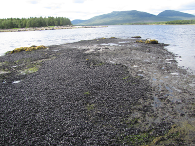

## Задание

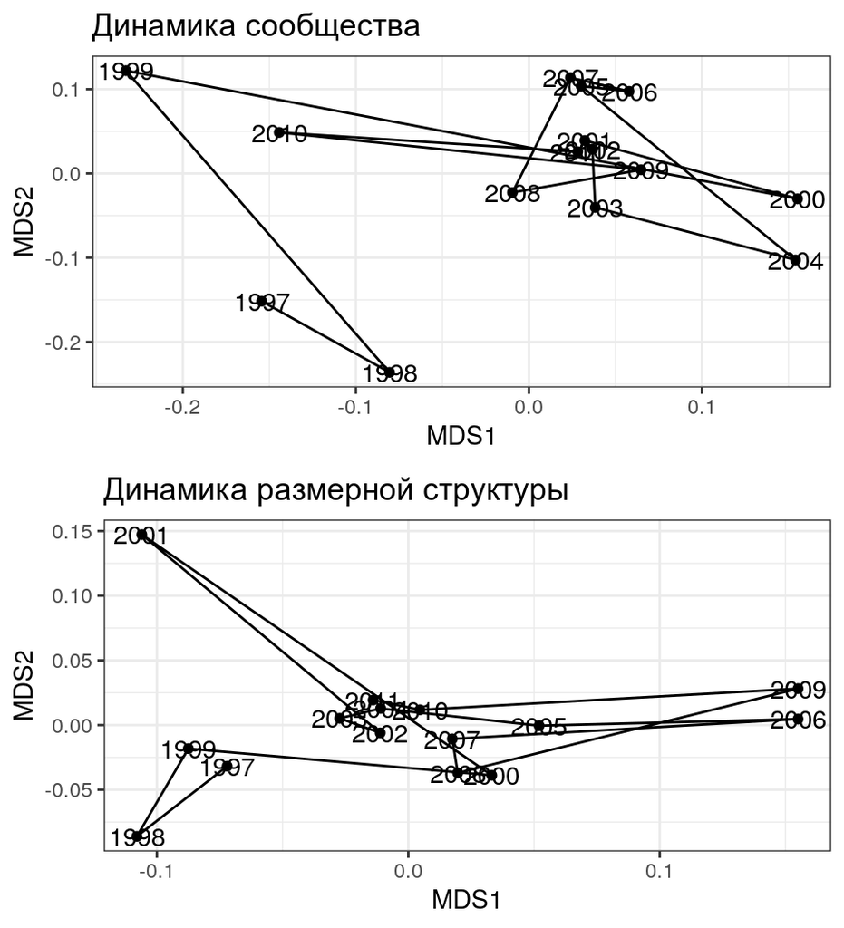

Рассмотрите многолетние изменения структуры сообщества и размерной структуры мидий на мидиевой банке Vor2

Постройте рисунок, аналогичный приведенному на данном слайде

Hint 1. Прологарифмируйте данные.

Hint 2. Примените наиболее подходящий коэффициент для оценки различий между объектами.

## Решение

### Ординация

```r
library(vegan)

log_com <- decostand(com[,-c(1:3)], method = "log")

vor2_log_com <- log_com[com$Bank == "Vor2",]

log_ascam <- decostand(ascam[, -c(1:2)], method = "log")

mds_vor2_com <- as.data.frame(metaMDS(vor2_log_com)$points)

vor2_log_ascam <- log_ascam[ascam$Bank == "Vor2",]

mds_vor2_ascam <- as.data.frame(metaMDS(vor2_log_ascam, distance = "euclid" )$points)
```

## Решение

### График ординации

```r
library(ggplot2)
library(gridExtra)
theme_set(theme_bw())

Pl1 <- ggplot(mds_vor2_com, aes(x=MDS1, y=MDS2)) + geom_point() +
  geom_path() + geom_text(label = com$Year[com$Bank == "Vor2"]) +
  ggtitle("Динамика сообщества")

Pl2 <- ggplot(mds_vor2_ascam, aes(x=MDS1, y=MDS2)) + geom_point() +
  geom_path() + geom_text(label = com$Year[com$Bank == "Vor2"]) +
  ggtitle("Динамика размерной структуры")

grid.arrange(Pl1, Pl2)
```

## Градиентная модельная матрица

Это матрица Евклидовых расстояний между временными точками.

```r
gradient_model <- vegdist(com$Year[com$Bank == "Vor2"], method="euclidian")
gradient_model
```

```
##     1  2  3  4  5  6  7  8  9 10 11 12 13 14
## 2   1
## 3   2  1
## 4   3  2  1
## 5   4  3  2  1
## 6   5  4  3  2  1
## 7   6  5  4  3  2  1
## 8   7  6  5  4  3  2  1
## 9   8  7  6  5  4  3  2  1
## 10  9  8  7  6  5  4  3  2  1
## 11 10  9  8  7  6  5  4  3  2  1
## 12 11 10  9  8  7  6  5  4  3  2  1
## 13 12 11 10  9  8  7  6  5  4  3  2  1
## 14 13 12 11 10  9  8  7  6  5  4  3  2  1
## 15 14 13 12 11 10  9  8  7  6  5  4  3  2  1
```

## Тестируем гипотезу о наличии градиента

Протестируем гипотезу о наличии временного градиента с помощью теста Мантела

```r
dist_vor2_com <- vegdist(vor2_log_com, method = "bray")
dist_vor2_ascam <- vegdist(vor2_log_ascam, method = "euclidean")
```

### 1) Наличие градиента в структуре сообщества

```r
mantel(dist_vor2_com, gradient_model)
```

```
##
## Mantel statistic based on Pearson's product-moment correlation
##
## Call:
## mantel(xdis = dist_vor2_com, ydis = gradient_model)
##
## Mantel statistic r: 0.264
##       Significance: 0.02
##
## Upper quantiles of permutations (null model):
##   90%   95% 97.5%   99%
## 0.164 0.214 0.254 0.289
## Permutation: free
## Number of permutations: 999
```

## Тестируем гипотезу о наличии градиента

### 2) Наличие градиента в размерной структуре мидий

```r
mantel(dist_vor2_ascam, gradient_model)
```

```
##
## Mantel statistic based on Pearson's product-moment correlation
##
## Call:
## mantel(xdis = dist_vor2_ascam, ydis = gradient_model)
##
## Mantel statistic r: 0.516
##       Significance: 0.001
##
## Upper quantiles of permutations (null model):
##   90%   95% 97.5%   99%
## 0.169 0.225 0.271 0.322
## Permutation: free
## Number of permutations: 999
```

## Прослеживается ли связь между размерной структурой мидий и структурой сообщества?

### Не самое правильное решение

```r
mantel(dist_vor2_com, dist_vor2_ascam)
```

```
##
## Mantel statistic based on Pearson's product-moment correlation
##
## Call:
## mantel(xdis = dist_vor2_com, ydis = dist_vor2_ascam)
##
## Mantel statistic r: 0.521
##       Significance: 0.004
##
## Upper quantiles of permutations (null model):
##   90%   95% 97.5%   99%
## 0.282 0.364 0.431 0.495
## Permutation: free
## Number of permutations: 999
```

## Прослеживается ли связь между размерной структурой мидий и структурой сообщества?

### Более корректное решение

```r
mantel.partial(dist_vor2_com, dist_vor2_ascam, gradient_model)
```

```
##
## Partial Mantel statistic based on Pearson's product-moment correlation
##
## Call:
## mantel.partial(xdis = dist_vor2_com, ydis = dist_vor2_ascam,      zdis = gradient_model)
##
## Mantel statistic r: 0.465
##       Significance: 0.022
##
## Upper quantiles of permutations (null model):
##   90%   95% 97.5%   99%
## 0.289 0.376 0.455 0.532
## Permutation: free
## Number of permutations: 999
```

## Могут быть и более сложные модельные матрицы

Проверим, нет ли в динамике размерной структуры мидий на банке Vor2 циклических изменений, которые предсказываются некоторыми моделями динамики плотных поселений (Наумов, 2006; Khaitov, Lentsman, 2016)

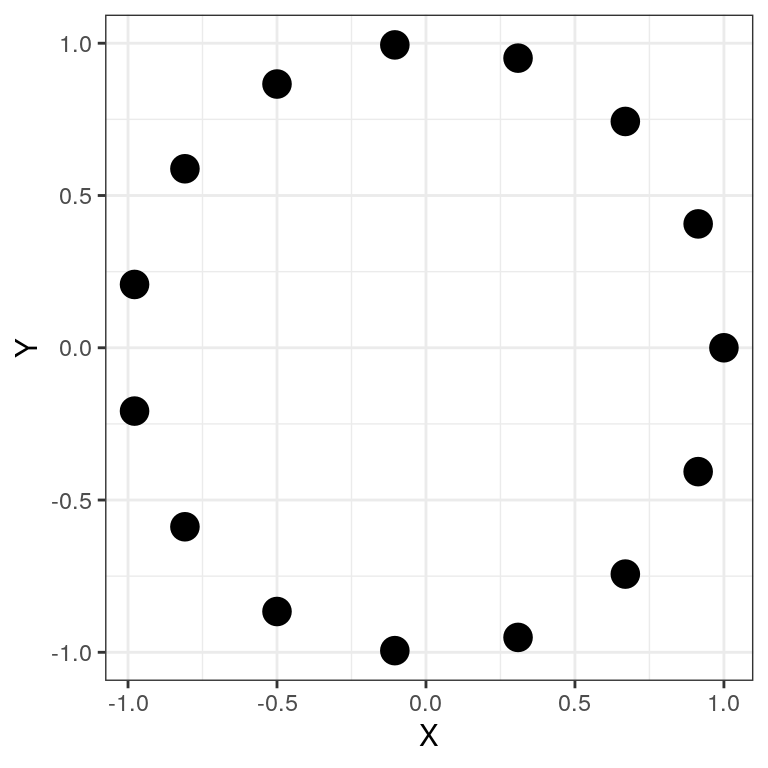

Циклическая модельная матрица

```
##    1 2 3 4 5 6 7 8 9 10 11 12 13 14
## 2  0
## 3  1 0
## 4  1 1 0
## 5  1 1 1 0
## 6  2 1 1 1 0
## 7  2 2 1 1 1 0
## 8  2 2 2 1 1 1 0
## 9  2 2 2 2 1 1 1 0
## 10 2 2 2 2 2 1 1 1 0
## 11 2 2 2 2 2 2 1 1 1  0
## 12 1 2 2 2 2 2 2 1 1  1  0
## 13 1 1 2 2 2 2 2 2 1  1  1  0
## 14 1 1 1 2 2 2 2 2 2  1  1  1  0
## 15 0 1 1 1 2 2 2 2 2  2  1  1  1  0
```

## Выявляется ли циклическая составляющая в динамике размерной структуры?

```r
mantel(dist_vor2_ascam, cycl_model)
```

```
##
## Mantel statistic based on Pearson's product-moment correlation
##
## Call:
## mantel(xdis = dist_vor2_ascam, ydis = cycl_model)
##
## Mantel statistic r: 0.173
##       Significance: 0.005
##
## Upper quantiles of permutations (null model):
##    90%    95%  97.5%    99%
## 0.0791 0.1085 0.1320 0.1537
## Permutation: free
## Number of permutations: 999
```

Циклическая составляющая есть, но…

## Более корректная оценка

```r
mantel.partial(dist_vor2_ascam, cycl_model, gradient_model)
```

```
##
## Partial Mantel statistic based on Pearson's product-moment correlation
##
## Call:
## mantel.partial(xdis = dist_vor2_ascam, ydis = cycl_model, zdis = gradient_model)
##
## Mantel statistic r: -0.137
##       Significance: 0.93
##
## Upper quantiles of permutations (null model):
##   90%   95% 97.5%   99%
## 0.124 0.155 0.186 0.225
## Permutation: free
## Number of permutations: 999
```

Мы не можем говорить о наличии столь длительного цикла.

При данной длине временного ряда нельзя отличить цикл с большим периодом от направленного изменения.

Можно обсуждать только циклы с периодом не более половины длины временного ряда.

## Подбор оптимальной модели: процедура BIO-ENV

## Постановка задачи

Необходимо выбрать предикторы, которые наилучшим образом объясняют поведение биологической системы.

\(NB!\) Эта задача аналогична задачам, ставящимся в регрессионном анализе.

К. Кларком и M. Эйнсвортом был предложен метод BIO-ENV (Clarke, Ainsworth, 1993). Это непараметрический аналог пошагового регрессионного анализа.

## Процедура BIO-ENV

В этом анализе есть две сцепленные матрицы:

- Зависимая матрица (BIO) - матрица геоботанических описаний.
- Матрица-предиктор (ENV) - матрица химических параметров.

## Алгоритм процедуры BIO-ENV

- Вычисляется матрица взаимных расстояний между объектами для зависимой матрицы \(D_{BIO}\). Используются все ее переменные.
- Матрица-предиктор имеет \(p\) переменных. Вычисляются все возможные матрицы взаимных расстояний между объектами для всех возможных комбинаций признаков матрицы ENV - \(D_{ENV_i}\). ВНИМАНИЕ! Таких матриц будет \(2^p-1\).
- Между каждой из матриц \(D_{ENV_i}\) и матрицей \(D_{BIO}\) вычисляется мантеловская корреляция.
- Находится матрица \(D_{ENV_i}\), имеющая максимальное значение мантеловской корреляции.
- Выводятся признаки матрицы ENV, на основе которых получена максимально подобная матрица \(D_{ENV_i}\).

## Функция bioenv() из пакета vegan

```r
BioEnv <- bioenv(varespec, varechem, method = "spearman", index = "bray")
```

```
## 16383 possible subsets (this may take time...)
```

```r
BioEnv
```

```
##
## Call:
## bioenv(comm = varespec, env = varechem, method = "spearman",      index = "bray")
##
## Subset of environmental variables with best correlation to community data.
##
## Correlations:    spearman
## Dissimilarities: bray
## Metric:          euclidean
##
## Best model has 5 parameters (max. 14 allowed):
## N P Al Mn Baresoil
## with correlation  0.4494
```

## Оценка достоверности результатов

**Внимание!** Не надо оценивать достоверность результата процедуры BIO-ENV путем оценки достоверности мантеловской корреляции между \(D_{BIO}\) и матрицей, полученной в результате применения BIO-ENV \(D_{ENV}\). **Это будет жульничеством**, так как это уже максимально подобная матрица.  
Для оценки достоверности полученного результата применяется пермутационный метод, основанный на **многократном повторении самой процедуры BIO-ENV**.  
Внимание! Это занимает очень много времени

## Алгоритм оценки достоверности применения процедуры BIO-ENV

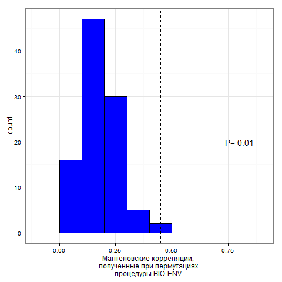

1. Применяем процедуру BIO-ENV и находим лучшее сочетание переменных в матрице-предикторе (ENV).
2. Пермутируем зависимую матрицу (BIO).
3. Применяем процедуру BIO-ENV к пермутированной матрице и вновь находим наилучшее сочетание и записываем значение мантеловской корреляции.
4. Повторяя шаги 2 и 3 многократно, получаем распределение пермутационных статистик.
5. Вычисляем уровень значимости способом, принятым при пермутационной оценке.

## Трактовка результатов BIO-ENV?

Задание: Постройте ординацию описаний в осях nMDS и отразите на этой диаграмме векторы, соответствующие результатам процедуры `BIO-ENV`

## Решение

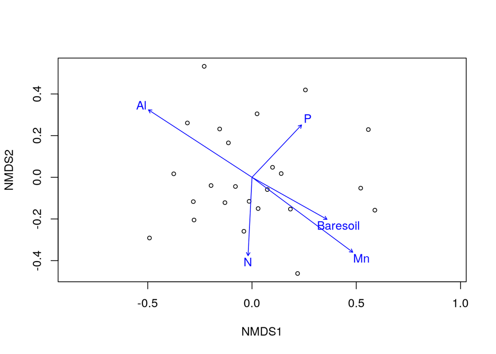

```r
plot(veg_ord, display = "site")
plot(envfit(veg_ord ~ N + P + Al + Mn + Baresoil, data = varechem ))
```

## Summary

- Степень сопряженности двух наборов признаков можно оценивать с помощью теста Мантела.
- Оценка достоверности теста Мантела и корреляций с признаками, вычисленными в процедуре `envfit()` проводится пермутационным методом
- С помощью процедуры `BIO-ENV` можно выявить набор переменных в матрице-предикторе, которые обеспечивают наибольшее сходство с зависимой матрицей.

## Другое программное обеспечение

PRIMER 6.

Здесь реализована расширенная процедура `BEST`.  
Она позволяет проводить не только полный перебор всех переменных в матрице-предикторе (Bio-Env), но и оптимизировать эту процедуру (BVStep). Кроме того, есть возможность оценивать достоверность результатов анализа. Но работает так же медленно.

## Что почитать

- Oksanen, J., 2011. Multivariate analysis of ecological communities in R: vegan tutorial. R package version 2–0.
- Clarke, K. R & Ainsworth, M. 1993. A method of linking multivariate community structure to environmental variables. Marine Ecology Progress Series, 92, 205–219.
- Clarke, K. R., Gorley R. N. (2006) PRIMER v6: User Manual/Tutorial. PRIMER-E, Plymouth.
- Legendre P., Legendre L. (2012) Numerical ecology. Second english edition. Elsevier, Amsterdam. (В этом издании приводятся ссылки на реализацию методов в R)